# Exercise 1

2- Generate QQ-plots of pH for good, bad and all wines to compare empirical quantiles of the samples to the theoretical quantiles of a normal distribution. Produce PP-plots for all three datasets. Comment on the differences between QQ-plots and PP-plots. Do you think all samples follow a normal distribution?

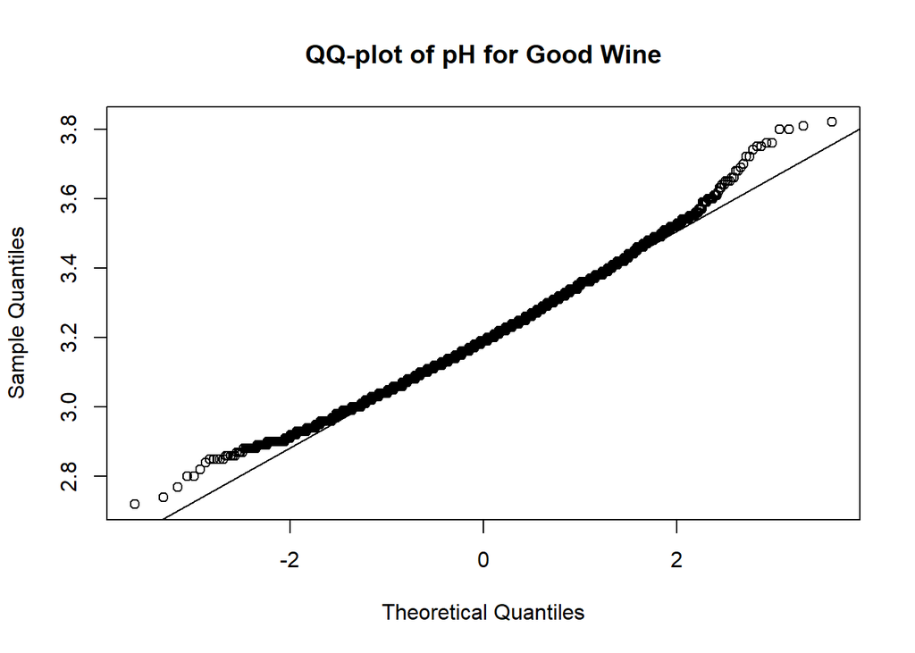

```r
qqnorm(good.wine$pH, main="QQ-plot of pH for Good Wine")
qqline(good.wine$pH)
```

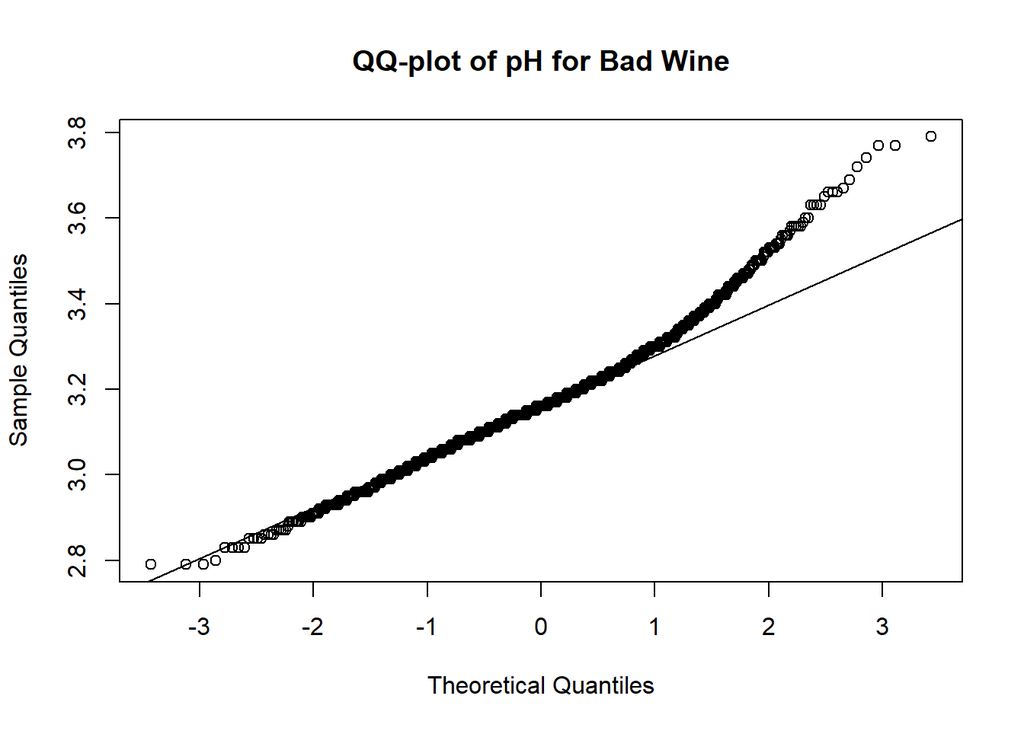

```r
qqnorm(bad.wine$pH, main="QQ-plot of pH for Bad Wine")
qqline(bad.wine$pH)
```

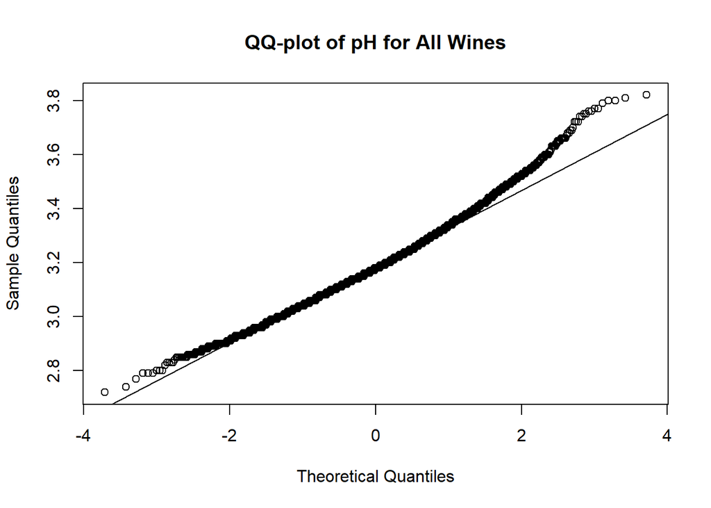

```r
qqnorm(white.wine.quality$pH, main="QQ-plot of pH for All Wines")
qqline(white.wine.quality$pH)
```

qqnorm() function plots the emprical distribution using ppoints() function in R. ppoints() uses (1:m - a)/(m + (1-a)-a) where m is either n, if length(n)==1, or length(n). And a by default a = if(n <= 10) 3/8 else 1/2). Good wine and all wine datasets seem to have a lighter left tail and heavier right tail than the theoretical normal distribution. Bad wine seems to only have heavier right tail but left tail seems to be more or less similar to the normal distribution.

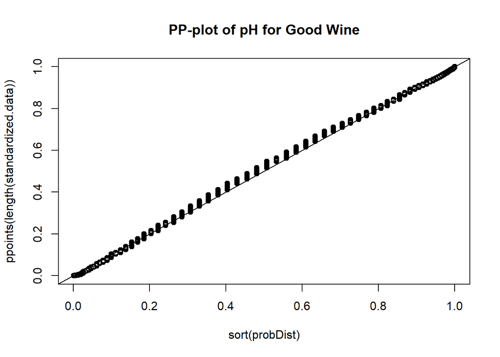

```r
standardized.data <- (good.wine$pH - mean(good.wine$pH)) / sd(good.wine$pH)
probDist <- pnorm(standardized.data)
plot(sort(probDist), ppoints(length(standardized.data)),
     main="PP-plot of pH for Good Wine")
abline(0,1)
```

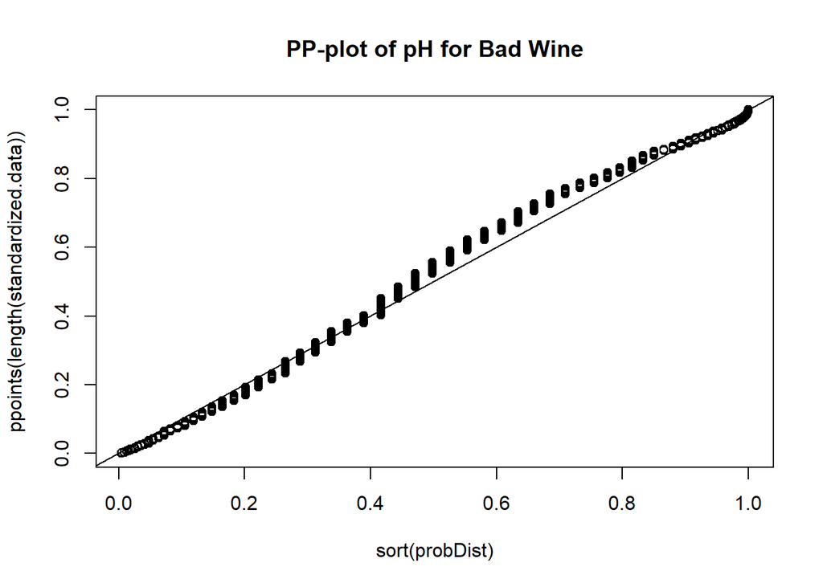

```r
standardized.data <- (bad.wine$pH - mean(bad.wine$pH)) / sd(bad.wine$pH)
probDist <- pnorm(standardized.data)
plot(sort(probDist), ppoints(length(standardized.data)),
     main="PP-plot of pH for Bad Wine")
abline(0,1)
```

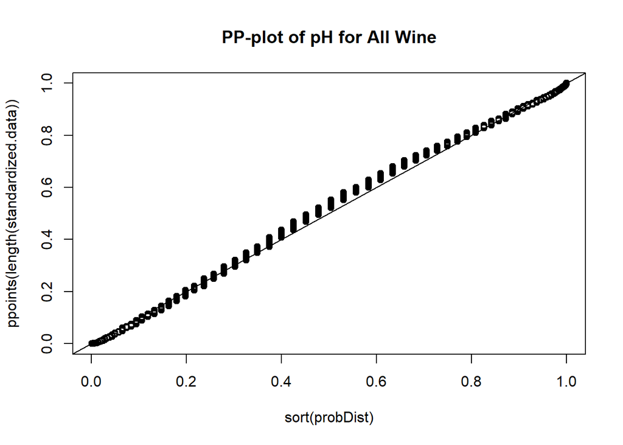

```r
standardized.data <- (white.wine.quality$pH - mean(white.wine.quality$pH)) / sd(white.wine.quality$pH)
probDist <- pnorm(standardized.data)
plot(sort(probDist), ppoints(length(standardized.data)),
     main="PP-plot of pH for All Wine")
abline(0,1)
```

The only difference between QQ and PP plot is that considering ECDFs on the same plot, whilst QQ-plot plots the corresponding values horizontally, PP-plot plots the vertical values. Therefore it makes more sense that tails are better expressed on qq-plot and mode is better expressed with pp-plot. Differences on tails are more clear on QQ-plots. But they more or less follow normal distributions.

3-) Plot the empirical distribution functions Fn for all three datasets. Add the pointwise confidence bands for α = 0.05 using the central limit theorem and Slutzky’s lemma (ensure that the confidence bands are in [0; 1]).

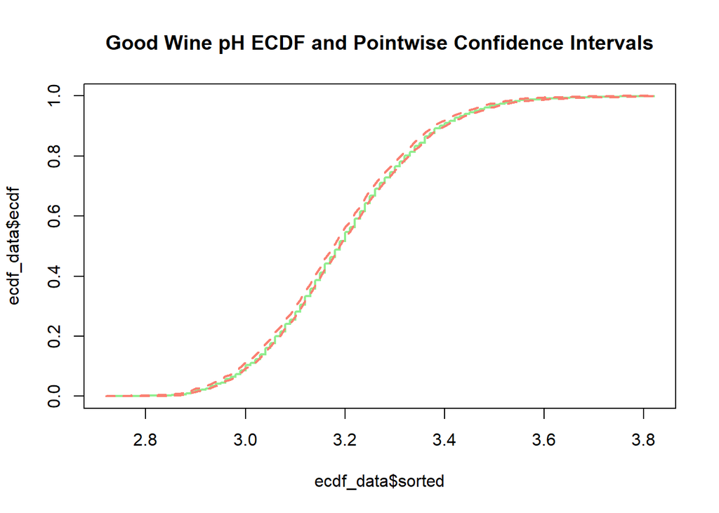

```r
ecdf.pwbands.plot <- function(data, title){
  ecdf_data <- ecdf.func(data)

  z <- sqrt(ecdf_data$ecdf*(1-ecdf_data$ecdf) / length(ecdf_data$ecdf))

  plot(ecdf_data$sorted,ecdf_data$ecdf , col="lightgreen",type = "s", lwd=2, main = title)

  upper_bound <- ecdf_data$ecdf + 1.96 * z
  lower_bound <- ecdf_data$ecdf - 1.96 * z
  upper_bound <- ifelse(upper_bound > 1, 1, upper_bound)
  lower_bound <- ifelse(lower_bound < 0, 0, lower_bound)

  lines(ecdf_data$sorted, upper_bound, lty = "dashed", col="salmon", lwd=2)
  lines(ecdf_data$sorted, lower_bound, lty = "dashed", col="salmon", lwd=2)
}

ecdf.pwbands.plot(good.wine$pH, "Good Wine pH ECDF and Pointwise Confidence Intervals")
```

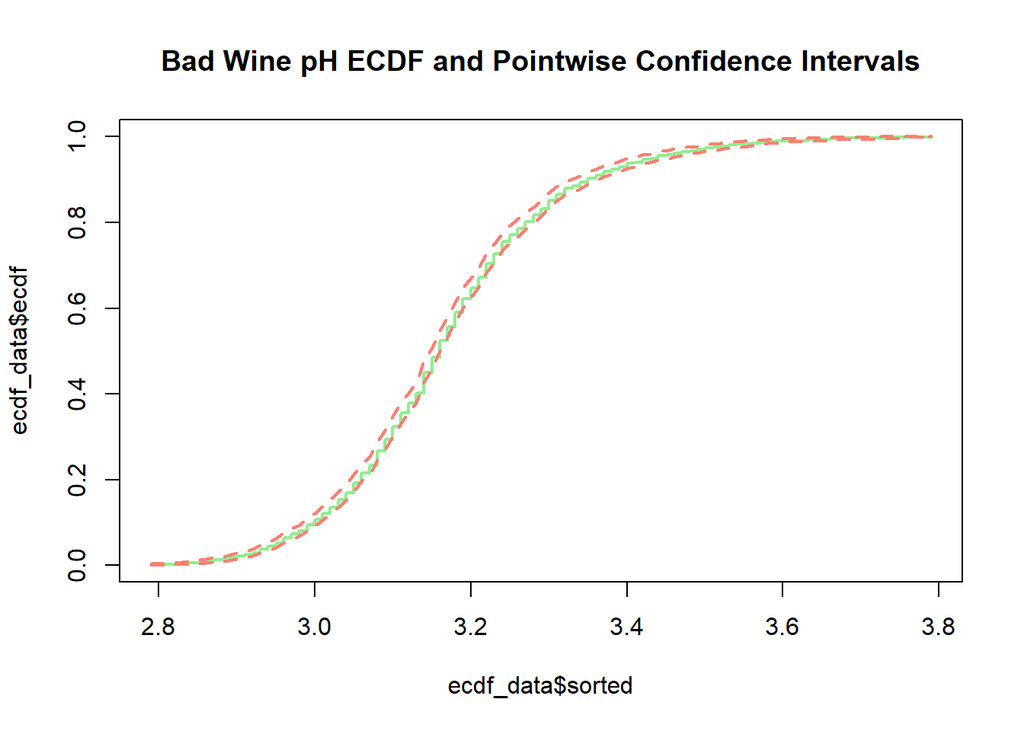

```r
ecdf.pwbands.plot(bad.wine$pH, "Bad Wine pH ECDF and Pointwise Confidence Intervals")
```

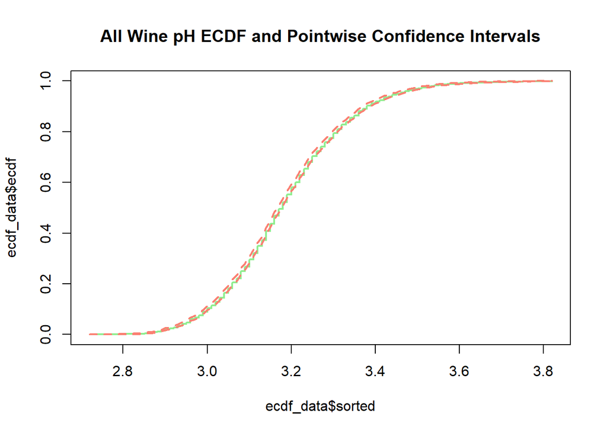

```r
ecdf.pwbands.plot(white.wine.quality$pH, "All Wine pH ECDF and Pointwise Confidence Intervals")
```

4- Plot the empirical distribution functions Fn for all three datasets together with the uniform confidence bands for α = 0.05. Compare to the bands obtained in (3).

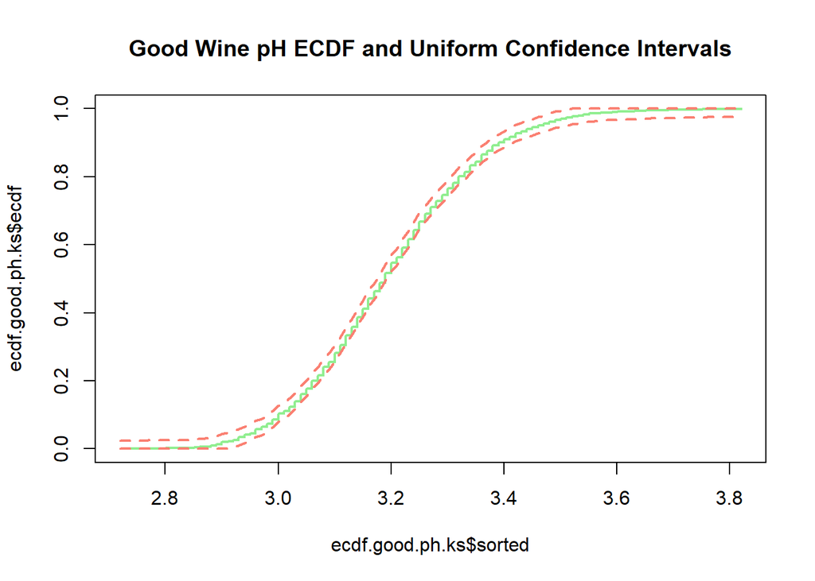

```r
ecdf.ksbands <- function(data) {
  ecdf_data <- ecdf.func(data)

  D <- 1.3581 / sqrt(length(data))
  upper_bound <- ecdf_data$ecdf + D
  lower_bound <- ecdf_data$ecdf - D
  upper_bound <- ifelse(upper_bound > 1, 1, upper_bound)
  lower_bound <- ifelse(lower_bound < 0, 0, lower_bound)

  return(list(sorted = ecdf_data$sorted, ecdf = ecdf_data$ecdf, upper_bound = upper_bound, lower_bound = lower_bound))
}


ecdf.good.ph.ks <- ecdf.ksbands(good.wine$pH)

plot(ecdf.good.ph.ks$sorted, ecdf.good.ph.ks$ecdf,type = "s", col="lightgreen", lwd=2, main = "Good Wine pH ECDF and Uniform Confidence Intervals")
lines(ecdf.good.ph.ks$sorted, ecdf.good.ph.ks$upper_bound, col="salmon", lwd=2, lty = "dashed")
lines(ecdf.good.ph.ks$sorted, ecdf.good.ph.ks$lower_bound, col="salmon", lwd=2, lty = "dashed")
```